# Adjustment Factors for Seasonality

```r
require(tidyverse)
require(data.table)
require(countrycode)
require(splitstackshape)

#Create a function for the exclusion operator %ni%
'%ni%' <- Negate('%in%')

#Calculate this up to June
final_week <- 24
```

First, we will calculate adjustment factors as in the previous code (the main change is that this time we will calculate mortality based on a 48 week year–not ideal, but necessary given the 4-week months. Is there a better fix for this?)

```r
#Load data and calculate weekly deaths for counterfactual and Covid cases
stmf <- fread("../Rcode/stmf-mar9-run.csv", stringsAsFactors = F)
names(stmf) <- tolower(names(stmf)) #Make names lowercase

#Keeping countries that only have data for 2020
keepcountry <- unique(stmf$countrycode[which(stmf$year == 2020)])

#Pivoting the STMF data into long format
adj.total <- stmf %>%
  dplyr::select(-c(split, splitsex, forecast)) %>% #removing variables
  filter(countrycode %in% keepcountry) %>%
  pivot_longer(-c(year, week, countrycode, sex),
               names_to = c("type", "age"), values_to = "rate", names_sep = 1) %>% #pivoting
  pivot_wider(names_from = "type", values_from = "rate") %>%
  mutate(death_count = d, #renaming and generating new versions of variables
         death_rate = r,
         age = gsub("85p", "85-99", gsub("_", "-", age)),
         country = countrycode,
         sex = if_else(sex %in% c("f"), "Female", if_else(sex %in% c("m"), "Male", "b"))) %>%
  filter(age != "total", between(year, 2016, 2020), sex != "b") %>%
  mutate(exposure = death_count/death_rate) %>%
  group_by(country, sex, age, year) %>%
  mutate(exposure2 = max(exposure, na.rm = T), #this accounts for the few cases where a weekly exposure is 0 due to no deaths in a group
         exposure_fixed = if_else(is.na(exposure), exposure2, exposure)) %>%
  dplyr::select(-c(exposure, exposure2, d,r, countrycode)) %>% #removing provisional and unnecessary variables
  rename(exposure = exposure_fixed) #specifying final exposure variable


#STMF currently reports the UK estimate for England and Wales, Scotland, and Northern Ireland separately; we combine them into one country and use that estimate for the UK
#Seeing if we need to adjust the UK estimate: we see if we have more than one containing the code GBR
adjustUK <- if_else(length(grep("GBR", levels(as.factor(adj.total$country)))) > 1, T, F)

#Print whether we need to adjust this
print(paste("UK estimate being constructed from", length(grep("GBR", levels(as.factor(adj.total$country)))), "entities"))
```

```
[1] "UK estimate being constructed from 3 entities"
```

```r
if (adjustUK <- T) {
  #England and Wales, Scotland, and NI may go up to different number of weeks.
  #Make sure we have the same number of weeks for each
  week_final_uk <-  adj.total %>%
    filter(grepl("GBR", country), year == 2020) %>%
    ungroup() %>%
    group_by(country) %>%
    summarize(max_week = max(week), .groups = "keep") %>%
    ungroup() %>%
    summarize(min_week = min(max_week)) %>%
    pull(min_week)

  #Now construct a single estimate for the UK
  adj.total.uk <- adj.total %>%
    filter(grepl("GBR", country) & week <= week_final_uk) %>%
    ungroup() %>%
    group_by(year, week, sex, age) %>%
    summarize(death_count = sum(death_count), exposure = sum(exposure), .groups = "keep") %>% #Adding up UK estimates
    mutate(country = "GBR") #Creating one country code

  adj.total2 <- adj.total %>%
    filter(!grepl("GBR", country)) %>% #Combining them with all other countries in the dataset
    bind_rows(adj.total.uk)
} else {
  adj.total2 <- adj.total
}
```

```r
#Now convert weekly data into monthly, and calculate mx values
#Now convert weekly data into monthly data
adj.monthly <- adj.total2 %>%
  filter(week <= 48) %>% #removing all data after a set cutoff point for comparability between countries, this is based on a 4-week month
  mutate(month = as.numeric(as.factor(cut(week, breaks = seq(1, 48+1, by = 4),
                                          right = FALSE)))) %>%
  ungroup() %>%
  group_by(country, year, month, sex, age) %>%
  summarize(death_count = sum(death_count), exposure = sum(exposure), .groups = "keep") %>% #generating monthly death counts and exposures
  mutate(period = if_else(year %in% c(2016:2019), "Past", "Current"))

#Making sure this worked
print(paste("UK estimates still need adjusting: ", if_else(length(grep("GBR", levels(as.factor(adj.monthly$country)))) > 1, T, F)))
```

```
[1] "UK estimates still need adjusting:  FALSE"
```

```r
#Now we can generate mx values for the two periods
  adj.past <- adj.monthly %>%  #Calculate average for past 4-year period
    filter(period == "Past") %>%
    ungroup() %>%
    group_by(country, month, sex, age) %>%
    summarize(mean_past_deaths = mean(death_count), mean_past_exposure =  mean(exposure),
              mean_past_mx = mean_past_deaths/mean_past_exposure, .groups = "keep")

  adj.current <- adj.monthly %>% filter(period == "Current") %>% #Find current mx values
    ungroup() %>%
    mutate(current_death_count = death_count, current_exposure = exposure,
           current_mx = current_death_count/current_exposure) %>%
    dplyr::select(-c(year, death_count, exposure, period))

  #Getting final monthly mx values
  adj.monthly.final <- left_join(adj.past, adj.current, #Combine past and current values
                                 by = c("country" = "country", "month" = "month", "sex" = "sex", "age" = "age")) %>%
    mutate(mean_past_mx = if_else(mean_past_mx == 0, 10^-6, mean_past_mx),
           mx_ratio_original = current_mx/mean_past_mx) %>% #Calculate adjustment factor
    separate(age, into = c("lower", "upper"), sep = "-", remove = F) %>% #Find upper and lower bounds of age intervals
    mutate(upper = as.numeric(upper),
           lower = as.numeric(lower),
           nrow = round((upper-lower)/5),
           nrow = if_else(lower == 0, nrow+1, nrow), #Calculating the number of 5-year intervals contained in a given interval
           country_name = ifelse(country == "TWN", "China Taiwan Province of China", #To match UN rates files
                                 countrycode(substr(country, 1, 3), origin = "iso3c", destination = "un.name.en")),
           country_name = c(gsub(" ", "_",
                                 gsub("United Kingdom of Great Britain and Northern Ireland",
                                      "United Kingdom", country_name)))) %>%
    filter(country %ni% c("TWN"))
```

Finally, we can calculate an annual average. Since the exposures are the same throughout, I suspect we could average the monthly deaths and then calculate a monthly mx value. Does this sound correct?

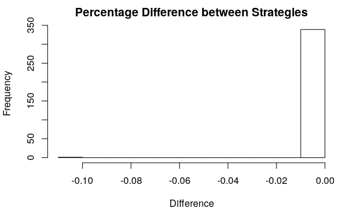

```r
monthly.average <- adj.monthly.final %>%
  ungroup() %>%
  group_by(country, sex, age) %>%
  summarize(annual_mean_past_deaths = mean(mean_past_deaths, na.rm = T),
            annual_exposure = mean(mean_past_exposure, na.rm = T),
            annual_mx = annual_mean_past_deaths/annual_exposure,
            .groups = "keep")

#Verifying that this is essential the same as calculating an average of the monthly mx values
verify.average <- adj.monthly.final %>%
  ungroup() %>%
  group_by(country, sex, age) %>%
  summarize(annual_mx_verify = mean(mean_past_mx, na.rm = T),
            .groups = "keep")

hist(100*(monthly.average$annual_mx-verify.average$annual_mx_verify)/verify.average$annual_mx_verify, main = "Percentage Difference between Strategies",
     xlab = "Difference")
```

Now merge this back so as to calculate the monthly adjustment factors.

```r
factors.merged <- merge(adj.monthly.final, monthly.average) %>%
  mutate(current_adj_factor = current_mx/annual_mx,
         past_adj_factor = mean_past_mx/annual_mx,
         current_v_past = current_adj_factor/past_adj_factor)
```

Now look at this for a few cases

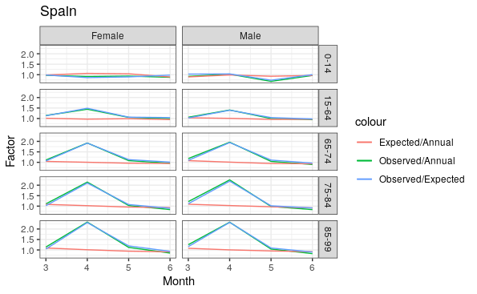

```r
factors.merged %>%
  filter(country_name == "Spain", month %in% c(3,4,5,6)) %>%
  ggplot() + geom_line(aes(x = month, y = current_adj_factor,
                           color = "Observed/Annual")) +
  geom_line(aes(x = month, y = past_adj_factor,
                           color = "Expected/Annual")) +
   geom_line(aes(x = month, y = mx_ratio_original,
                           color = "Observed/Expected")) +
  facet_grid(rows = vars(age), cols = vars(sex)) +
  labs(x = "Month", y = "Factor", title = "Spain") +
  theme_bw()
```

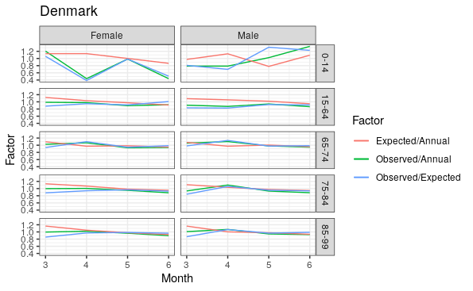

```r
factors.merged %>%
  filter(country_name == "Denmark", month %in% c(3,4,5,6)) %>%
  ggplot() + geom_line(aes(x = month, y = current_adj_factor,
                           color = "Observed/Annual")) +
  geom_line(aes(x = month, y = past_adj_factor,
                           color = "Expected/Annual")) +
   geom_line(aes(x = month, y = mx_ratio_original,
                           color = "Observed/Expected")) +
  facet_grid(rows = vars(age), cols = vars(sex)) +
  labs(x = "Month", y = "Factor", title = "Denmark", color = "Factor") +
  theme_bw()
```

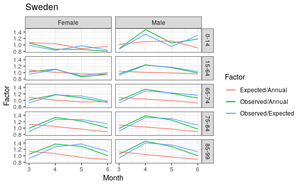

```r
factors.merged %>%
  filter(country_name == "Sweden", month %in% c(3,4,5,6)) %>%
  ggplot() + geom_line(aes(x = month, y = current_adj_factor,
                           color = "Observed/Annual")) +
  geom_line(aes(x = month, y = past_adj_factor,
                           color = "Expected/Annual")) +
   geom_line(aes(x = month, y = mx_ratio_original,
                           color = "Observed/Expected")) +
  facet_grid(rows = vars(age), cols = vars(sex)) +
  labs(x = "Month", y = "Factor", title = "Sweden", color = "Factor") +
  theme_bw()
```

This seems to suggest that it is worth adjusting for seasonality, even if it does not seem to affect all countries in the sample equally.

Let us investigate one final thing, the extent to which the new Covid adjustment factors are higher than the counterfactual ones. The results suggest that Covid excess mortality is still reflected in our adjustment factors.

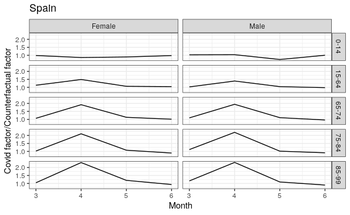

```r
factors.merged %>%
  filter(country_name == "Spain", month %in% c(3,4,5,6)) %>%
  ggplot() + geom_line(aes(x = month, y = current_v_past)) +
  facet_grid(rows = vars(age), cols = vars(sex)) +
  labs(x = "Month", y = "Covid factor/Counterfactual factor", title = "Spain") +
  theme_bw()
```

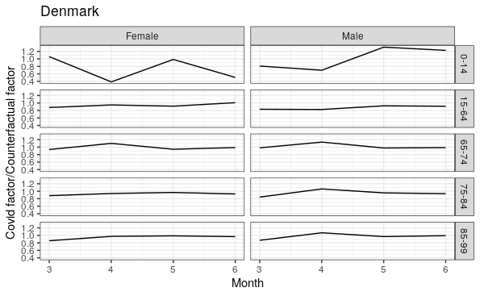

```r
factors.merged %>%
  filter(country_name == "Denmark", month %in% c(3,4,5,6)) %>%
  ggplot() + geom_line(aes(x = month, y = current_v_past)) +
  facet_grid(rows = vars(age), cols = vars(sex)) +
  labs(x = "Month", y = "Covid factor/Counterfactual factor", title = "Denmark") +
  theme_bw()
```

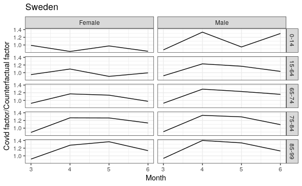

```r
factors.merged %>%
  filter(country_name == "Sweden", month %in% c(3,4,5,6)) %>%
  ggplot() + geom_line(aes(x = month, y = current_v_past)) +
  facet_grid(rows = vars(age), cols = vars(sex)) +
  labs(x = "Month", y = "Covid factor/Counterfactual factor", title = "Sweden") +
  theme_bw()
```

Questions that remain:

1. Do we like this approach?
2. How do we feel about the 48-week year and the issue with converting weeks to months? Is this an acceptable simplification, or are there better ways to do it?